# Musterlösung: Übungsaufgabe 3

Statistische Modellbildung II

17.November 2017

**Datenaufbereitung aus vorheriger Woche**

```r
*Alter.
compute alter0= v84-18.
variable labels alter0 "Alter mit 18 als Nullpunkt".

frequencies alter0.


*Bildung.
Recode v86 (1=0) (2=1) (3=2) (4=3) (5=4) (else=SYSMIS) into bildung_rec.
variable labels bildung_rec "Abschluss umkodiert".
value labels bildung_rec 0"Kein Schulabschluss" 1"Hauptschule" 2"Realschule" 3"Fachhochschulreife" 4"Abi".

frequencies bildung_rec.


*Geschlecht.
Recode v81 (2=0) (1=1) (else=copy) into geschl_rec.
variable labels geschl_rec "Geschlecht mit w=0".
value labels geschl_rec 0"weiblich" 1"mÃ¤nnlich".

frequencies geschl_rec.


*Einkommen.
COMPUTE einkommen = v420.

frequencies einkommen.
```

## Aufgabe 1

*Was ist unter einer Dummy-Variablen zu verstehen, wozu wird sie benötigt und wie ist sie zu interpretieren?*

Dummy-Variablen sind binär codierte Variablen, die i.d.R. die Ausprägungen 0 und 1 haben. Sie werden für die Berücksichtigung der Effekte von Variablen, die eine nominale oder ordinale Skalierung aufweisen, wie z.B. Geschlecht oder Bildung, verwendet. Der Wert 1 beschreibt dabei das Vorliegen des bestimmten Merkmals, während ein Fall den Wert 0 erhält, wenn das Merkmal nicht vorliegt. Für die Erstellung von DummyVariablen aus einer Variable mit mehreren, nicht metrischen Ausprägungen wird die Ausgangsvariable in k-1 dichotome Variablen zerlegt, d.h. eine Variable weniger, als Ausprägungen vorliegen. Die übrig gebliebene Ausprägung stellt die Referenzkategorie für die anderen Dummy-Variablen dar.

## Aufgabe 2

*Erstellen Sie aus der Bildungsvariablen “eine” Dummyvariable. Führen Sie eine Regression von Einkommen auf Alter, Bildung und Geschlecht durch:*

```r
COMPUTE ohne_abschluss = bildung_rec = 0.
COMPUTE hauptschule = bildung_rec = 1.
COMPUTE realschule = bildung_rec = 2.
COMPUTE fachhoch = bildung_rec = 3.
COMPUTE hochschul = bildung_rec = 4.

REGRESSION
  /DEPENDENT einkommen
  /METHOD=ENTER alter0 ohne_abschluss realschule fachhoch
                                    hochschul geschl_rec.
```

ModellzusammenfassungModellzusammenfassung, Tabelle, 1 Stufen von Spaltenüberschriften und 1 Stufen von Zeilenüberschriften, Tabelle mit 5 Spalten und 4 Zeilen

| Modell | R | R-Quadrat | Korrigiertes R-Quadrat | Standardfehler des Schätzers |
| --- | --- | --- | --- | --- |
| 1 | ,462<sup>a</sup> | ,214 | ,212 | 4,39058 |

a. Einflußvariablen : (Konstante), Geschlecht mit w=0, Alter mit 18 als Nullpunkt, ohne_abschluss, fachhoch, realschule, hochschul

Koeffizienten<sup>a</sup>Koeffizienten, Tabelle, 2 Stufen von Spaltenüberschriften und 2 Stufen von Zeilenüberschriften, Tabelle mit 7 Spalten und 11 Zeilen

| Modell |  | Nicht standardisierte Koeffizienten |  | Standardisierte Koeffizienten | T | Sig. |  |  |
| --- | --- | --- | --- | --- | --- | --- | --- | --- |
|  |  | RegressionskoeffizientB | Standardfehler | Beta |  |  |  |  |
| 1 | (Konstante) | 6,195 | ,264 |  |  |  | 23,437 | ,000 |
|  | Alter mit 18 als Nullpunkt | ,041 | ,005 | ,144 | 8,492 | ,000 |  |  |
|  | ohne_abschluss | -1,399 | ,646 | -,036 | -2,164 | ,031 |  |  |
|  | realschule | 1,526 | ,209 | ,146 | 7,307 | ,000 |  |  |
|  | fachhoch | 3,391 | ,323 | ,187 | 10,504 | ,000 |  |  |
|  | hochschul | 3,693 | ,222 | ,334 | 16,606 | ,000 |  |  |
|  | Geschlecht mit w=0 | 3,563 | ,160 | ,360 | 22,266 | ,000 |  |  |

a. Abhängige Variable: einkommen

### Aufgabe 2a

*Interpretieren Sie die Koeffizienten für “Abitur” und “Realschulabschluss”. Achten Sie genau auf Ihre Formulierung.*

Eine 18-jährige weibliche Person mit einem Volks- oder Hauptschulabschluss verdient laut Modell 1 durschnittlich 6,20 Einkommenseinheiten. Eine 18-jährige weibliche Person mit einem Realschulabschluss verdient 1,53 Einkommenseinheiten mehr als eine gleichaltrige weibliche Person mit einem Volks- oder Hauptschulabschluss (b=1.53, p<0.001), unter Kontrolle des Alters und Geschlecht. Eine 18-jährige weibliche Person mit Abitur verdient 3,69 Einkommenseinheiten mehr als eine gleichaltrige weibliche Person mit einem Volks- oder Hautpschulabschluss (b=3.69, p<0.001), unter Kontrolle des Alters und Geschlecht.

## Aufgabe 3

*Was ist unter einer Moderatorvariable zu verstehen und auf welche Weise(n) kann der Einfluss eines Moderatoreffektes untersucht werden? Erklären Sie kurz das Vorgehen hierbei.*

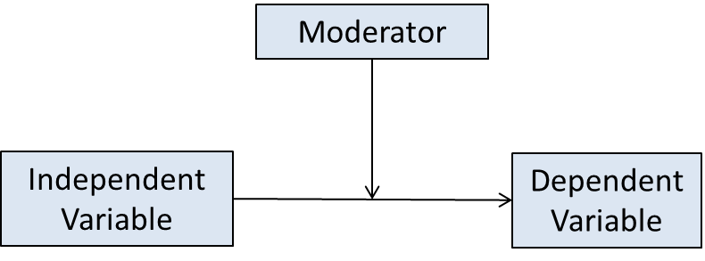

Moderatoreffekt

Eine Moderatorvariable ist eine Variable *z* welche einen Einfluss auf den Effekt zwischen einer *x* und einer *y* Variable ausübt. Also in dem hier angewandten Beispiel hat die Moderatorvariable “Geschlecht” einen Einfluss darauf, wie Alter auf Einkommen wirkt, also auf den Effekt von Alter auf Einkommen. Eine Moderatorvariable beeinflusst also nicht die Ausprägung einer Variable, sondern sie beeinflusst die Beziehung zwischen x und y. Denn da wo z (also die Moderatorvariable) variiert, dort variiert auch der Effekt von Alter auf Einkommen.

Ein Moderatoreffekt kann auf zwei verschiedene Weisen betrachtet werden. Eine Lösung wäre, eine *Interaktionsvariable* zu erstellen. Das heißt man multipliziert die z (Moderator-) Variable und die x (UV) Variable miteinander und bezieht diese mit in das Regressionsmodell. Durch die Multiplikation kann die Interaktionsvariable nur dann einen Wert annehmen, wenn beide Variablen einen Wert angenommen haben sonst wäre die Interaktionsvariable schließlich 0. Nun kann man beispielsweise prüfen, ob der Alterseffekt (auf Einkommen) sich in Abhängigkeit vom Geschlecht, also der Moderatorvariable, verändert. Hier ist also wichtig, dass nur, wenn auch die Ausgangsvariablen berücksichtigt werden, der Interaktionseffekt auch etwas aussagen kann. Problematisch kann hier sein, dass dann die Signifikanz der Originalvariablen abfällt, bedingt durch Multikollinearität.

Deshalb gibt es noch eine zweite Lösung: *Einen Multigruppenvergleich.* Man splittet des Datensatz anhand der Moderatorvariable, z.B. nach weiblich und männlich, rechnet die Regression für beide Gruppen und vergleicht dann. Problematisch hier kann werden, dass die Signifikanz der Moderatoreffekte nur auf umständliche Weise geprüft werden kann.

## Aufgabe 4

*Erstellen Sie eine Interaktionsvariable zwischen Geschlecht und Alter und reduzieren Sie vor den folgenden Regressionsanalysen den Datensatz, um die Fälle, bei denen die Geburtenentscheidungen keine besondere Bedeutung mehr für die Gehaltsentwicklung haben sollten (Alter unter 46 Jahren -> SELE IF Alter_0 < 28). Modell 1 enthält dann Alter und Geschlecht, in Modell 2 kommt die Interaktionsvariable hinzu.*

```r
*Interaktionsvariable erstellen.

compute ageschl_int = alter0 * geschl_rec.

*Filter erstellen.
*TEMPORARY.
SELECT IF alter0 < 28.

*Regression ohne Interaktion.
REGRESSION
  /DEPENDENT einkommen
  /METHOD=ENTER alter0 geschl_rec.
```

ModellzusammenfassungModellzusammenfassung, Tabelle, 1 Stufen von Spaltenüberschriften und 1 Stufen von Zeilenüberschriften, Tabelle mit 5 Spalten und 4 Zeilen

| Modell | R | R-Quadrat | Korrigiertes R-Quadrat | Standardfehler des Schätzers |
| --- | --- | --- | --- | --- |
| 1 | ,471<sup>a</sup> | ,222 | ,221 | 4,35906 |

a. Einflußvariablen : (Konstante), Geschlecht mit w=0, Alter mit 18 als Nullpunkt

Koeffizienten<sup>a</sup>Koeffizienten, Tabelle, 2 Stufen von Spaltenüberschriften und 2 Stufen von Zeilenüberschriften, Tabelle mit 7 Spalten und 7 Zeilen

| Modell |  | Nicht standardisierte Koeffizienten |  | Standardisierte Koeffizienten | T | Sig. |  |  |
| --- | --- | --- | --- | --- | --- | --- | --- | --- |
|  |  | RegressionskoeffizientB | Standardfehler | Beta |  |  |  |  |
| 1 | (Konstante) | 5,757 | ,293 |  |  |  | 19,660 | ,000 |
|  | Alter mit 18 als Nullpunkt | ,232 | ,016 | ,371 | 14,709 | ,000 |  |  |
|  | Geschlecht mit w=0 | 3,002 | ,250 | ,304 | 12,023 | ,000 |  |  |

a. Abhängige Variable: einkommen

```r
REGRESSION
  /DEPENDENT einkommen
  /METHOD=ENTER alter0 geschl_rec ageschl_int.
```

ModellzusammenfassungModellzusammenfassung, Tabelle, 1 Stufen von Spaltenüberschriften und 1 Stufen von Zeilenüberschriften, Tabelle mit 5 Spalten und 4 Zeilen

| Modell | R | R-Quadrat | Korrigiertes R-Quadrat | Standardfehler des Schätzers |
| --- | --- | --- | --- | --- |
| 1 | ,504<sup>a</sup> | ,254 | ,252 | 4,27231 |

a. Einflußvariablen : (Konstante), ageschl_int, Alter mit 18 als Nullpunkt, Geschlecht mit w=0

Koeffizienten<sup>a</sup>Koeffizienten, Tabelle, 2 Stufen von Spaltenüberschriften und 2 Stufen von Zeilenüberschriften, Tabelle mit 7 Spalten und 8 Zeilen

| Modell |  | Nicht standardisierte Koeffizienten |  | Standardisierte Koeffizienten | T | Sig. |  |  |
| --- | --- | --- | --- | --- | --- | --- | --- | --- |
|  |  | RegressionskoeffizientB | Standardfehler | Beta |  |  |  |  |
| 1 | (Konstante) | 7,470 | ,374 |  |  |  | 19,979 | ,000 |
|  | Alter mit 18 als Nullpunkt | ,115 | ,023 | ,184 | 5,084 | ,000 |  |  |
|  | Geschlecht mit w=0 | -,172 | ,507 | -,017 | -,339 | ,735 |  |  |
|  | ageschl_int | ,221 | ,031 | ,407 | 7,148 | ,000 |  |  |

a. Abhängige Variable: einkommen